# BCB420 Assignment1

Ishan Sharma

Install required packages:

```r
if (!requireNamespace("BiocManager", quietly = TRUE))
    install.packages("BiocManager")
if (!requireNamespace("GEOmetadb", quietly = TRUE))
    BiocManager::install("GEOmetadb")
```

The GEO database contains dataset on gene expressions but can be tough to navigate online. It is better to use the GEOmetadb package and sort through the metadata using SQLite queries to design the experiment. Let’s look at the tables GEO provides and sort through it to find a dataset to work on.

```r
library(knitr)
library(GEOmetadb)
if(!file.exists('GEOmetadb.sqlite')) getSQLiteFile()
```

[output not shown]

Getting some information about file and its contents:

```r
file.info('GEOmetadb.sqlite')
```

[output not shown]

The dbConnect function helps us format the dataset into a more R suitable table format. Remember to disconnect connections with SQLlite files after use.

```r
con <- dbConnect(SQLite(),'GEOmetadb.sqlite')
geo_tables <- dbListTables(con)
geo_tables
```

[output not shown]

DEFINING THE OBJECT INFO FUNCTION This code was adapted from lecture material and was primarily used to understand table data pulled from GEO during the course of this assignment.

```r
objectInfo <- function(x) {
     # Function to combine various information items about R objects
     #
     # Input: an R object
     # Value: none - prints information as side-effect

     cat("object contents:")
     print(x, digits = 22)  # print value at maximal precision

     cat("\nstructure of object:\n")
     str(x)

     if (! is.list(x)) { # Don't use cat() if x is a list. cat() can't handle lists.
         cat("\nmode:   ", mode(x), "\n")
         cat("typeof: ", typeof(x), "\n")
         cat("class:  ", class(x), "\n")
     }

     # if the object has attributes, print them too
     if (! is.null(attributes(x))) {
        cat("\nattributes:\n")
         attributes(x)
     }
     # Done
 }
```

Looking for RNAseq data sets according to a1 requirements. We know the tag high-throughput sequencing appeared in uniq tech, this is the word for RNAseq. Since I wanted to do bulk RNAseq analysis, I’ll look for data that helps me do that with human tissues. The data is recent (last 10 years).

```r
sql <- paste("SELECT DISTINCT gse.title,gse.gse, gpl.title,",
             " gse.submission_date,",
             " gse.supplementary_file",
             "FROM",
             "  gse JOIN gse_gpl ON gse_gpl.gse=gse.gse",
             "  JOIN gpl ON gse_gpl.gpl=gpl.gpl",
             "WHERE",
             "  gse.submission_date > '2011-01-01' AND",
             "  gpl.organism LIKE '%Homo sapiens%' AND",

             "  gpl.technology LIKE '%high-throughput sequencing%' ",
             "  ORDER BY gse.submission_date DESC",sep=" ")
rs <- dbGetQuery(con,sql)
# break the file names up and just get the actual file name
unlist(lapply(rs$supplementary_file,
              FUN = function(x){x <- unlist(strsplit(x,";")) ;
              x <- x[grep(x,pattern="txt",ignore.case = TRUE)]; # we want a txt file
                tail(unlist(strsplit(x,"/")),n=1)})) [1:10]
rs <- dbGetQuery(con,sql)
# we only want supp files which are counts
counts_files <- rs$supplementary_file[grep(rs$supplementary_file,
                              pattern = "count",ignore.case = TRUE)]
knitr::kable(counts_files, format = "html")

# Silences the disconnect warning:
dbDisconnect((con))
```

[output not shown]

Get Information on The supplementary files with the chosen dataset. Make a separate directory in this one to access downloaded data. This function’s extra parameters are relaly helpful to do all the fetching and organising of supplementary files from the dataset.

```r
supp_files =  getGEOSuppFiles('GSE154583', makeDirectory = TRUE, baseDir = getwd(),
  fetch_files = TRUE)
supp_files
```

|  | size | isdir | mode | mtime | ctime | atime | uid | gid | uname | grname |
| --- | --- | --- | --- | --- | --- | --- | --- | --- | --- | --- |
| /home/rstudio/projects/GSE154583/GSE154583_counts_data.txt.gz | 1065094 | FALSE | 644 | 2021-03-11 18:22:29 | 2021-03-11 18:22:29 | 2021-03-02 15:32:19 | 1000 | 1000 | rstudio | rstudio |
| /home/rstudio/projects/GSE154583/GSE154583_norm_counts_data.txt.gz | 4505196 | FALSE | 644 | 2021-03-11 18:22:45 | 2021-03-11 18:22:45 | 2021-03-11 18:22:29 | 1000 | 1000 | rstudio | rstudio |

```r
counts_data = read.delim("GSE154583/GSE154583_counts_data.txt.gz",header=TRUE,
             check.names = FALSE, stringsAsFactors = FALSE, sep = " ")
#normal_counts_data = #read.delim("GSE154583/GSE154583_norm_counts_data.txt.gz",header=TRUE,
 #            check.names = FALSE, sep = " ")
# get a little more sense about how the data frame is structured
counts_data[1:10, 1:8]
```

|  | P1 | P2 | P3 | P4 | P5 | P6 | P7 | P8 |
| --- | --- | --- | --- | --- | --- | --- | --- | --- |
| A1BG | 55 | 15 | 63 | 21 | 43 | 77 | 39 | 53 |
| A1CF | 0 | 0 | 0 | 0 | 0 | 0 | 0 | 0 |
| A2LD1 | 89 | 23 | 48 | 40 | 89 | 139 | 50 | 83 |
| A2M | 0 | 9 | 0 | 23 | 3 | 0 | 3 | 0 |
| A2ML1 | 0 | 0 | 0 | 0 | 0 | 0 | 0 | 0 |
| A2MP1 | 0 | 0 | 0 | 0 | 0 | 0 | 0 | 0 |
| A4GALT | 6 | 5 | 0 | 3 | 0 | 2 | 34 | 25 |
| A4GNT | 0 | 0 | 0 | 0 | 0 | 0 | 0 | 0 |
| AAAS | 484 | 173 | 456 | 236 | 282 | 432 | 310 | 323 |
| AACS | 134 | 75 | 125 | 80 | 143 | 233 | 160 | 223 |

```r
library("edgeR")
cpms = cpm(counts_data[, 1:8])
rownames(cpms) <- counts_data[,1]
# get rid of low counts
donor1 = rowSums(cpms >1) >=8  # following the edgeR protocol
counts_filtered = counts_data[donor1,]

#dim(counts_filtered)
#counts_filtered

#
```

FILTERING.. There are 4 Donors- D1, D2, D3 AND D4 in the study and two blood cell types: ‘naive’ and ‘MBC’. Three types of tissues were sampled - Spleen, ileum and blood tissues. Spleen has 4 biological replicates and ileum (gut) has 3. From a thorough reading of the experiment, I was able to form some groupings to start decoding what the column names refer to. Here are my findings: All donors sampled for both naive and MBC blood type. All P samples are from D1 and all MN samples are from D2. No P samples are of ileum or blood tissues. No MN sample is of blood tissue. NW 12-16, 20-27, 30 are of D3 and come from all three tissues. NW 17,18, 19, 29, 31, 33-35, 39-41 are of D4 and come from all three tissues

For now I will choose to work with Donor1 spleen tissue sample and try to analyse the differences between naive cell and Memory B cell types.

```r
samples <- data.frame()
samples <-rbind(samples, data.frame(P1="naive", P2 = "naive", P3="naive", P4="naive", P5 = "MBC", P6="MBC", P7="MBC", P8="MBC"))
colnames(samples) <- colnames(counts_data)[1:8]
rownames(samples) <- c("cell_type")
samples <- data.frame(t(samples))
samples
```

|  | cell_type |
| --- | --- |
| P1 | naive |
| P2 | naive |
| P3 | naive |
| P4 | naive |
| P5 | MBC |
| P6 | MBC |
| P7 | MBC |
| P8 | MBC |

Now that I have grouped the data, I’ll do some cleaning. The code fragment below prepares a list for differential gene analysis that we’ll be performing in assignment 2

```r
filtered_data_matrix <- as.matrix(counts_filtered[,1:8])

dgeList = DGEList(counts=filtered_data_matrix, group=samples$cell_type)
dgeList
```

```
An object of class "DGEList"
$counts
        P1  P2  P3  P4  P5   P6  P7  P8
A1BG    55  15  63  21  43   77  39  53
A2LD1   89  23  48  40  89  139  50  83
AAAS   484 173 456 236 282  432 310 323
AACS   134  75 125  80 143  233 160 223
AAGAB 1029 415 960 514 767 1238 782 999
10265 more rows ...

$samples
```

|  | group | lib.size | norm.factors |
| --- | --- | --- | --- |
| P1 | naive | 24038262 | 1 |
| P2 | naive | 8163368 | 1 |
| P3 | naive | 21064879 | 1 |
| P4 | naive | 9718260 | 1 |
| P5 | MBC | 16839280 | 1 |
| P6 | MBC | 23980495 | 1 |
| P7 | MBC | 15734400 | 1 |
| P8 | MBC | 22914662 | 1 |

```
NA
```

Calculate normalised factors in our DGE list. This data is now cleaner and we can read it better by plotting BCV graphs.

```r
dgeList = calcNormFactors(dgeList)
normalized_counts <- cpm(dgeList)
normalized_counts[1:10,]
```

```
              P1        P2        P3        P4        P5        P6       P7        P8
A1BG    2.212062  1.805109  2.908630  2.081300  2.556808  3.416242  2.42736  2.491974
A2LD1   3.579519  2.767833  2.216099  3.964380  5.291998  6.166982  3.11200  3.902525
AAAS   19.466149 20.818920 21.052942 23.389844 16.767903 19.166448 19.29440 15.186934
AACS    5.389388  9.025543  5.771092  7.928761  8.502873 10.337459  9.95840 10.485097
AAGAB  41.385677 49.941341 44.321984 50.942288 45.606319 54.926070 48.67168 46.971353
AAK1    2.413159 25.030841  5.771092 14.569098  4.102785  4.126110  6.53520  3.996562
AAMP   26.544749 30.686848 33.841681 38.950037 35.676390 37.534293 32.30256 34.746577
AARS   53.531910 64.141529 57.803254 60.159472 45.487398 43.346341 70.45568 44.338324
AARS2  32.456988 31.529232 27.932084 25.867582 24.795091 24.934129 34.04528 21.487396
AARSD1 15.967069 11.071333 16.297563 23.588063 14.330017 16.105140 14.31520 17.866981
```

Let’s see how this lools like on a graph. Samples with similar gene expressions tend to cluster together. In the plot below, we can see samples with MBC typle blood cell clustering up, however there is still a good amount of variance in our samples.

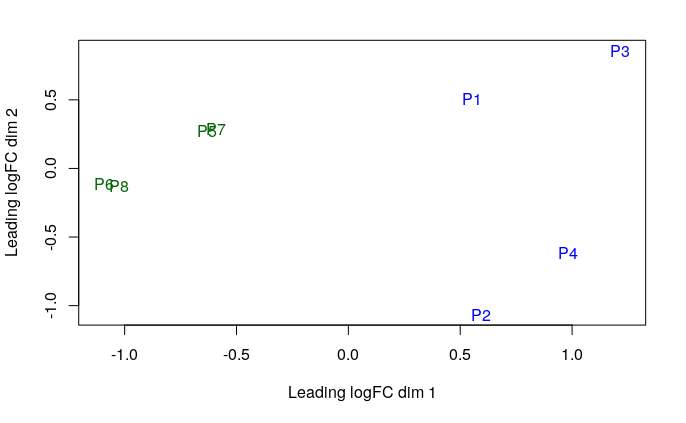

```r
plotMDS(dgeList, labels=rownames(samples),
  col = c("darkgreen","blue")[factor(samples$cell_type)])
```

Calculating dispersion: I’m just using cell_type here for the model design so that edgeR can show us the variance of genes across samples.

```r
model_design <- model.matrix(~samples$cell_type+0)
dgeList <- estimateDisp(dgeList, model_design)
dgeList
```

```
An object of class "DGEList"
$counts
        P1  P2  P3  P4  P5   P6  P7  P8
A1BG    55  15  63  21  43   77  39  53
A2LD1   89  23  48  40  89  139  50  83
AAAS   484 173 456 236 282  432 310 323
AACS   134  75 125  80 143  233 160 223
AAGAB 1029 415 960 514 767 1238 782 999
10265 more rows ...

$samples
```

|  | group | lib.size | norm.factors |
| --- | --- | --- | --- |
| P1 | naive | 24038262 | 1.0343375 |
| P2 | naive | 8163368 | 1.0179314 |
| P3 | naive | 21064879 | 1.0282366 |
| P4 | naive | 9718260 | 1.0382362 |
| P5 | MBC | 16839280 | 0.9987271 |
| P6 | MBC | 23980495 | 0.9399050 |
| P7 | MBC | 15734400 | 1.0211281 |
| P8 | MBC | 22914662 | 0.9281517 |

```
$design
  samples$cell_typeMBC samples$cell_typenaive
1                    0                      1
2                    0                      1
3                    0                      1
4                    0                      1
5                    1                      0
6                    1                      0
7                    1                      0
8                    1                      0
attr(,"assign")
[1] 1 1
attr(,"contrasts")
attr(,"contrasts")$`samples$cell_type`
[1] "contr.treatment"


$common.dispersion
[1] 0.04858095

$trended.dispersion
[1] 0.09386121 0.09266136 0.05549595 0.08083424 0.03486776
10265 more elements ...

$tagwise.dispersion
[1] 0.05088045 0.07654164 0.02625809 0.04758583 0.01828233
10265 more elements ...

$AveLogCPM
[1] 1.401064 2.006655 4.283374 3.091186 5.583214
10265 more elements ...

$trend.method
[1] "locfit"

$prior.df
[1] 4.267343

$prior.n
[1] 0.7112239

$span
[1] 0.3023312
```

This is how the BCV graph looks like for the above dispersion. Note that genes with more counts will have smaller variations between samples than genes with few counts.

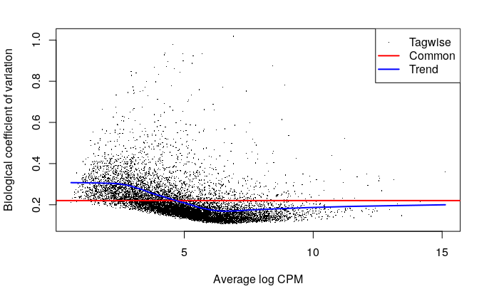

```r
plotBCV(dgeList,col.tagwise = "black",col.common = "red",)
```

We can also see the mean variance relationship for this sample:

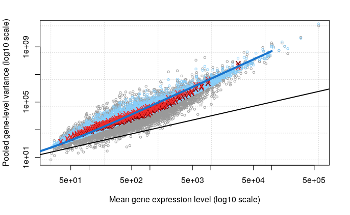

```r
plotMeanVar(dgeList, show.raw.vars = TRUE, show.tagwise.vars=TRUE,
            show.ave.raw.vars = TRUE,  NBline=TRUE,
            show.binned.common.disp.vars = TRUE)
```

[output not shown]